# ETC5521 Assignment 1

Infrastructural Investment in USA

Aphiaut Imuan

Xintong You

2022-08-26

This assignment is for ETC5521 Assignment 1 by Team lorikeet comprising of Aphiaut Imuan and Xintong You.

# 1 Introduction and motivation

Infrastructure investment is an important core of the country. It includes federal investments such as water suppliers and a private sector investment that manages electricity. It also includes the cost of research and development in technology.

Moreover, infrastructure investment plays a role in supporting both businesses and households. For example, the development of logistics has resulted in businesses reducing transportation costs. Households can access infrastructure services and can choose to use them. It also has a positive effect on both short-term and long-term economic growth [(Stupak, 2017)](https://ecommons.cornell.edu/bitstream/handle/1813/78289/CRS_Economic_Impact_of_Infrastructure_Investment_0717.pdf?sequence=1&isAllowed=y).

The above mentioned, the case study of infrastructure should be USA because the USA is a big country, has a large population, and people can access infrastructure services. Furthermore, the USA is also the world’s largest economy.

# 2 Data description

The data comes from [Bureau of Economic Analysis](https://www.bea.gov/system/files/papers/BEA-WP2020-12.pdf). The raw .xlsx file is included, or can be downloaded directly from the [BEA Working paper series](https://www.bea.gov/system/files/2021-01/infrastructure-data-may-2020.xlsx).

The 3 primary data sets are already cleaned and saved as .csv files and they all have five variables. Of these, the four variables are the same as below.

| variable | class | description | e.g. |
| --- | --- | --- | --- |
| category | character | Category of investment | Private,Federal… |
| meta_cat | character | Group category of investment | Total infrastructure,Water supply,GDP… |
| group_num | double | Group number of investment | 1,2,3… |
| year | double | Year of investment | 1947,1948,1949… |

The 3 data sets record the gross investment, chained investment in millions of USD and Implicit Price Deflators (IPDs) respectively.

| variable | class | description |
| --- | --- | --- |
| gross_inv | double | Gross investment in millions of USD |
| gross_inv_chain | double | Gross investment (chained 2021 dollars) in millions of USD |
| gross_inv_ipd | double | Implicit Price Deflators (IPDs) An implicit price deflator is the ratio of the current-dollar value of a series, such as gross domestic product (GDP), to its corresponding chained-dollar value, multip… |

The gdplev data set is downloaded from [Bureau of Economic Analysis](https://www.bea.gov/data/gdp/gross-domestic-product), which is a supplementary data set for our analysis. It records the current GDP and chain GDP in US from 1929 to 2021. Its variable contains year, GDP_current and GDP_chain whose type is all double.

- Chained dollars: Chained dollars is a method of adjusting real dollar amounts for inflation over time, to allow the comparison of figures from different years. The U.S. Department of Commerce introduced the chained-dollar measure in 1996.

# 3 Questions of interest

1. What category of investment is the highest average gross investment and Chain? Does it same?
2. What is the trend of total basic infrastructure?
3. what is the trend of total social infrastructure?
4. What year and category are the highest investment and Chain?
5. What year and category are the lowest investment and Chain?
6. **What is the relationship between total digital investment and GDP?**
7. What are the highest investment between Air, Water, Rail transportation investment ?
8. What are the similarities/difference of trend between Federal electric power structures investment and Private electric power structures investment?
9. How does the digital investment change?
10. How does the transportation investment change?
11. How does the power investment change?
12. What is the proportion of total social investment in all category infrastructure?
13. What is the proportion of total basic infrastructure investment in all category infrastructure?
14. **What is the relationship between transportation investment (chained US dollars) and GDP (chained US dollars)?**
15. What are the trends in all categories infrastructure investment so far?
16. In 2012, what is the proportion of various investments in the total investment？
17. What category of investment has the greatest impact on GDP and how?
18. **What is the relationship between GDP and private investment, federal investment？And which one is stronger impact on GDP?**
19. What is the proportion of total digital investment in all category infrastructure?
20. **Is there a linear relationship between GDP and total basic infrastructure investment? Positive or negative?**

# 4 Expected findings

In question 6: We expect the positive relationship between total data investment and GDP. Moreover we expect to see the steep line from 1900 to 2017.

In question 14: We expect the positive relationship between transportation (chained US dollar) and GDP (chained US dollar), the result can explain by the linear model and high effect value to GDP.

In question 18: We expect a strong relationship between GDP and federal investment, and both relations are positive linear relationships.

In question 20: We expect there is a positive linear relationship between GDP and total basic. infrastructure investment.

# 5 Analysis and findings

**Methodology**

This study uses the linear model to analysis because linear models are the simple and present a mathematical equation which easy to interpret and can be predictions. Moreover, the linear regression model is a reliable predictors because it is a long established statistical procedure and the character of linear regression is easy to understand (IBM, 2022).

**What is the relationship between total digital investment and GDP?**

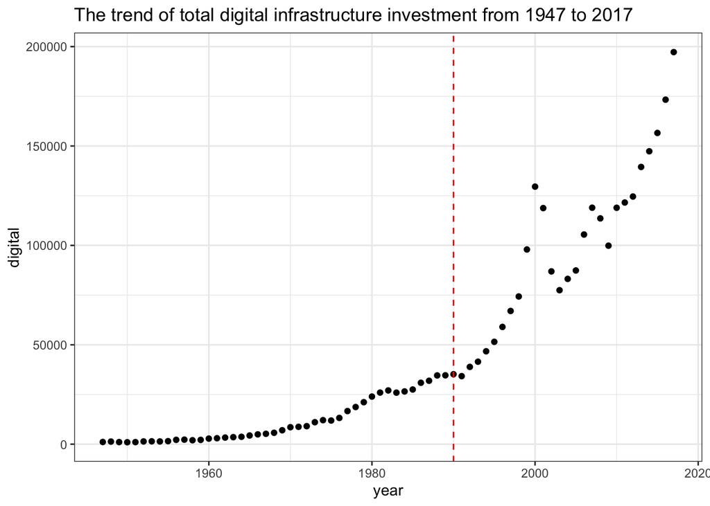

Figure 5.1: The trend of total digital infrastructure investment from 1947 to 2017

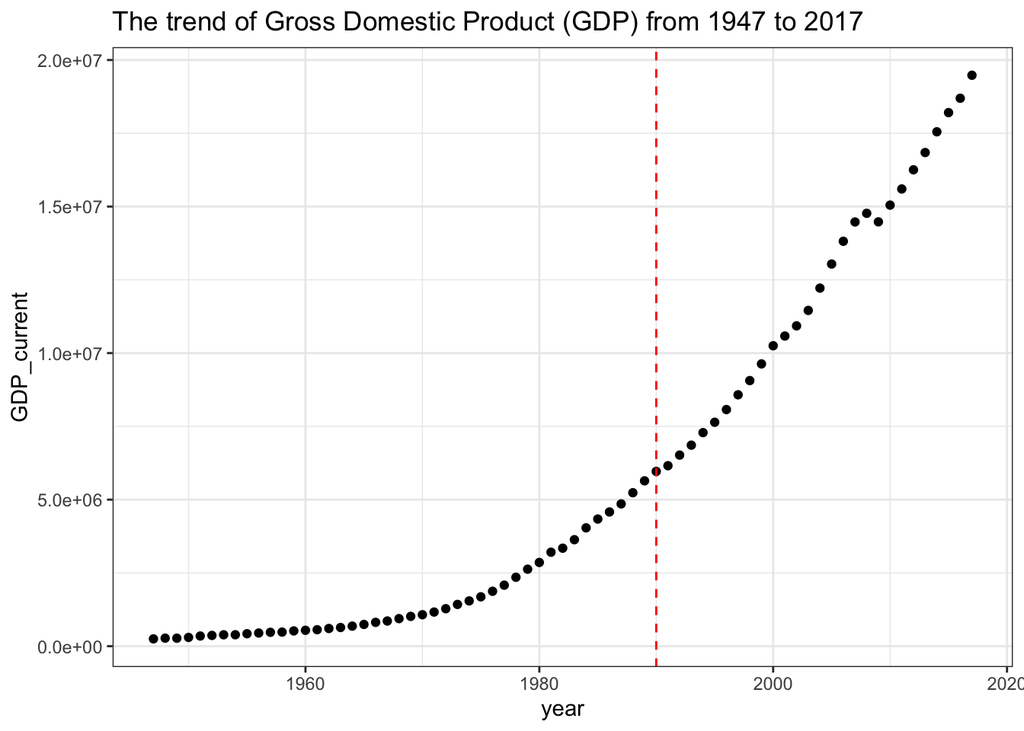

Figure 5.2: The trend of Gross Domestic Product (GDP) from 1947 to 2017

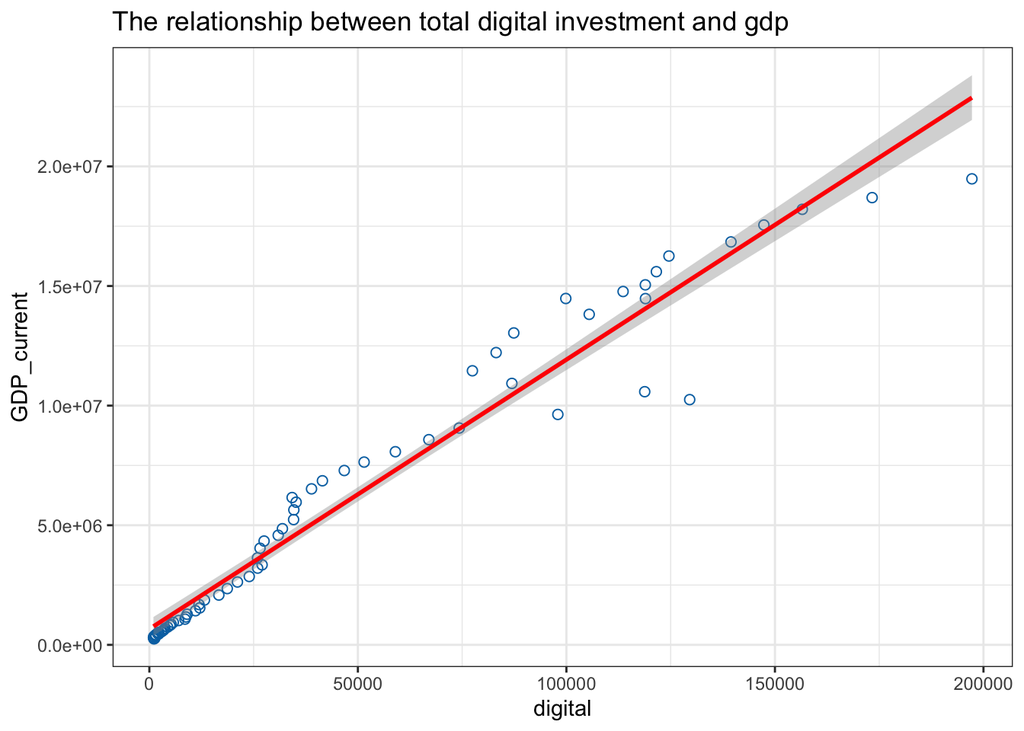

Figure 5.3: The relationship between total digital investment and gdp

| term | estimate | std.error | statistic | p.value |
| --- | --- | --- | --- | --- |
| (Intercept) | 659595.9744 | 1.998196e+05 | 3.300957 | 0.0015277 |
| digital | 112.6322 | 2.929285e+00 | 38.450403 | 0.0000000 |

| r.squared | adj.r.squared | sigma | statistic | p.value | df | logLik | AIC | BIC | deviance | df.residual | nobs |
| --- | --- | --- | --- | --- | --- | --- | --- | --- | --- | --- | --- |
| 0.95541 | 0.9547638 | 1254559 | 1478.434 | 0 | 1 | -1096.733 | 2199.466 | 2206.254 | 1.086003e+14 | 69 | 71 |

The table of results can be expressed in the formula as:

$$\begin{align*}
{GDP} = 659595.97 + 112.63{digital}
\end{align*}$$

This formula means if total digital infrastructure increases by 1 million US dollars, the Gross Domestic Product will increase by 112.63 million US dollars. This result is related to the study of Zhang et al. (2022) that investigated the increase of digital economy will increase the GDP by around 0.78%. Furthermore, they told it can be seen by the development of new technology such as the internet and mobile phone communication. R-squared is 95.54% of the variance and it shows a nice linear model. Therefore, the result of a relationship between total digital infrastructure and GDP can be summarised by the linear model.

In Addition, this result same as our expected finding which is a positive relationship between total digital infrastructure and GDP. However, the trend of Total digital infrastructure has steeply increased since 1990, and GDP has steeply increased since 1980. It means total digital infrastructure doesn’t significantly affect GDP from 1980 to 1990.

**What is the relationship between transportation investment (chained US dollars) and GDP (chained US dollars)?**

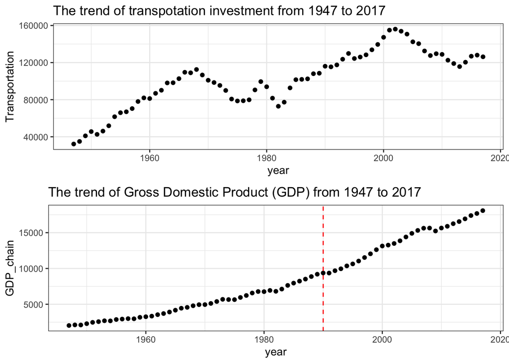

Figure 5.4: The trend of transpotation investment and Gross Domestic Product (GDP) from 1947 to 2017

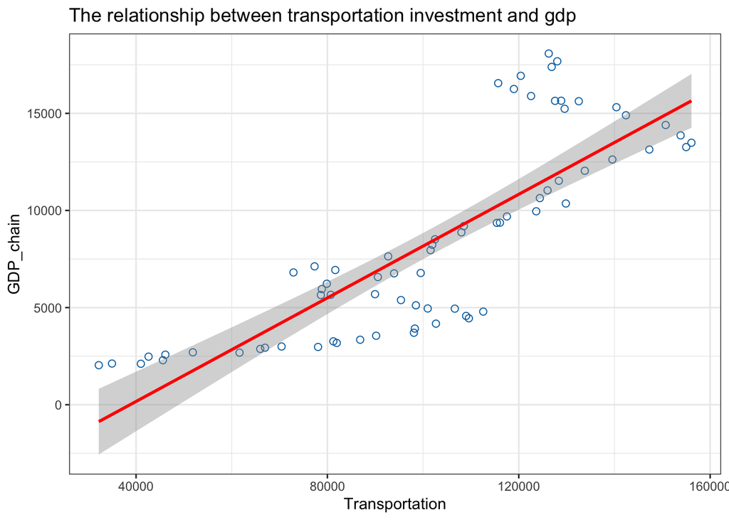

Figure 5.5: The relationship between transportation investment and gdp

| term | estimate | std.error | statistic | p.value |
| --- | --- | --- | --- | --- |
| (Intercept) | -5164.8342269 | 1185.5828124 | -4.356367 | 4.5e-05 |
| Transportation | 0.1333108 | 0.0111639 | 11.941235 | 0.0e+00 |

| r.squared | adj.r.squared | sigma | statistic | p.value | df | logLik | AIC | BIC | deviance | df.residual | nobs |
| --- | --- | --- | --- | --- | --- | --- | --- | --- | --- | --- | --- |
| 0.6739024 | 0.6691764 | 2852.588 | 142.5931 | 0 | 1 | -664.605 | 1335.21 | 1341.998 | 561470681 | 69 | 71 |

Figure 5.4 shows the positive trend of transportation investment (chained dollar), however, it is a steeply slight fluctuation between 1968 and 1998. While Gross Domestic Product (chained dollar) is a positive trend and increases over the year. Figure 5.5 illustrates the relationship between transportation investment (chained dollar) and GDP (chained dollar), nonetheless, it is difficult to explain the relationship between both variables as linear.

The table of results can be expressed in the formula as:

$$\begin{align*}
{GDP} = -5164.83 + 0.13{Transportation}
\end{align*}$$

This formula means if transportation investment increases by 1 million chained US dollars, the Gross Domestic Product will increase by 0.13 million chained US dollars. This result relates to the study of Weisbrod and Reno (2009) that argued the positive significance of the relationship between transportation investment and GDP. Moreover, transportation investment has a positive effect on economic growth (Lin, 2020). R-squared is 67.39% of the variance. Therefore, the result of the relationship between transportation investment (chained dollar) and Gross Domestic Product (chained dollar) should not summary by a linear model, or this formula has omitted variables.

This result same as our expected finding that is a positive relationship between transportation investment (chained dollar) and Gross Domestic Product (chained dollar). However, this relationship can not explain by the linear model and the coefficient is too low which is not the same as our expected finding.

**What is the relationship between GDP and private investment, federal investment？And which one is stronger impact on GDP?**

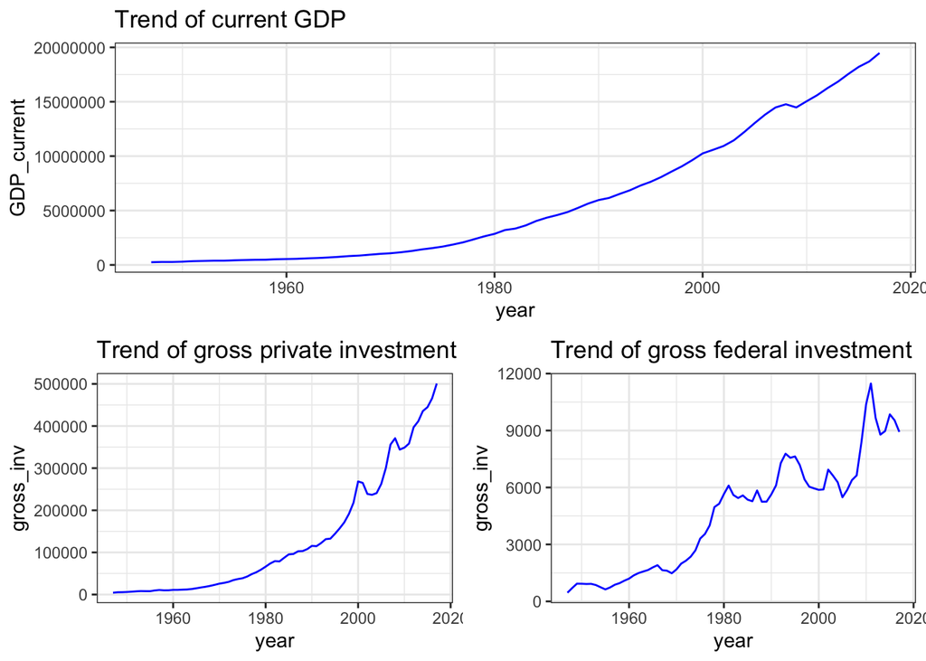

Figure 5.6: The trends of private, federal investment and current GDP

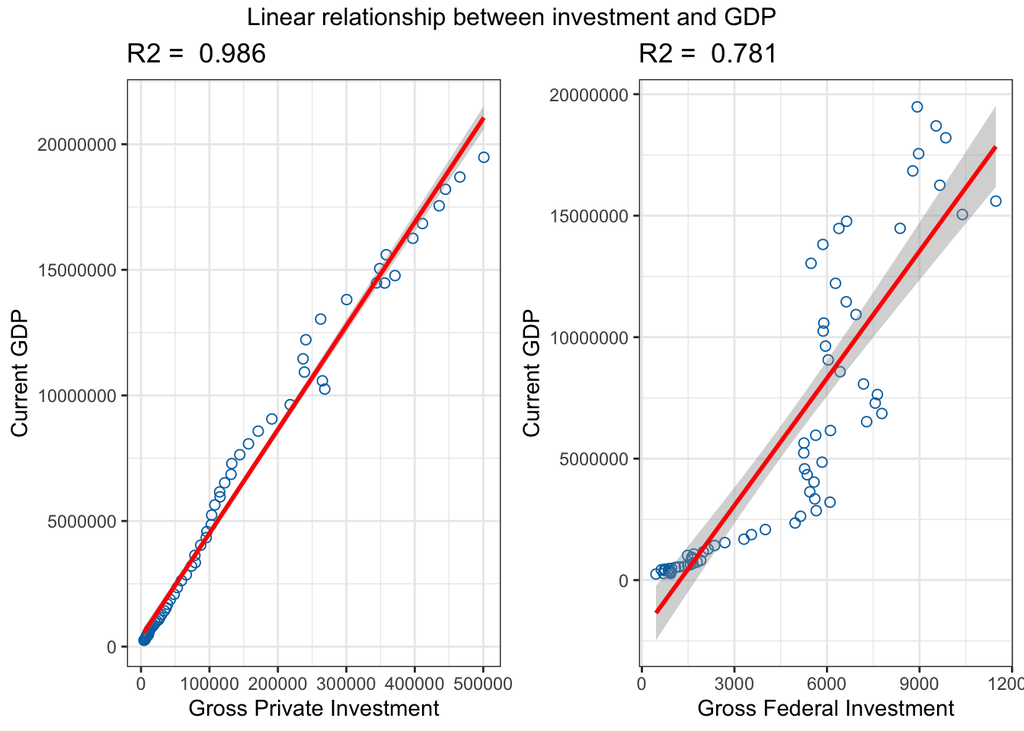

Figure 5.7: The relationship between investment and GDP

By observing the trends of the three variables, this study predicts the current GDP and the other two might have a linear relationship, then we use a linear model to judge whether they have a linear relationship. As a result, GDP does have a linear relationship with private investment and federal investment respectively, and private investment has a stronger impact on current GDP.

R-squared is an important statistical measure that represents the proportion of the variance for current GDP that is explained by the gross private and federal investment in the regression model. For example, Figure 5.7 shows that 98.6% of private investment can explain the current GDP, rather only 78.1% of federal investment can explain that. Obviously, there is a stronger linear relationship between GDP and private investment which is unexpected. This result relates to the study of Private investment as the engine of economic growth and social welfare that investigated the private investment can explain the variance of GDP growth rate more than public investment (Doménech & Sicilia, 2021).

Therefore, this results same as our expected finding that is the relationship between both variable and GDP is a linear model. However, the R-squared of federal investment is not as expected finding because the R-squared of private investment is much more valuable.

**Is there a linear relationship between GDP and total basic infrastructure investment? Positive or negative?**

| term | estimate | std.error | statistic | p.value |
| --- | --- | --- | --- | --- |
| (Intercept) | -337073.45 | 117823.9903 | -2.861 | 0.0056 |
| gross_inv | 59.02 | 0.8235 | 71.672 | 0.0000 |

| r.squared | adj.r.squared | sigma | statistic | p.value | df | logLik | AIC | BIC | deviance | df.residual | nobs |
| --- | --- | --- | --- | --- | --- | --- | --- | --- | --- | --- | --- |
| 0.9867 | 0.9866 | 683988 | 5137 | 0 | 1 | -1054 | 2113 | 2120 | 32280928200607 | 69 | 71 |

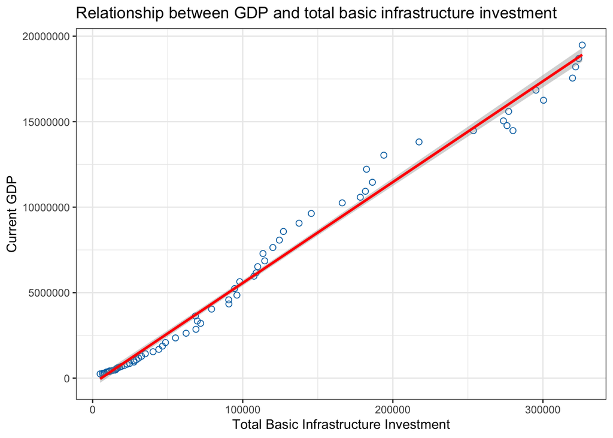

Figure 5.8: The relationship between GDP and total basic infrastructure investment

From the result can be expressed the formula as:

$$\begin{align*}
{GDP} = -337073.45 + 59.02 {Basic}
\end{align*}$$

Additionally, these results can confirm the expected finding is correct by the graph, the result of regression, and R-square.